# Modelos ARIMA

2020-04-20

```r
library(easypackages)
libraries("tidyverse","fpp3", "patchwork")
```

Los modelos ARIMA son otra metodología para realizar pronósticos de series de tiempo. Estos y los modelos de suavización exponencial son los métodos más comúnmente utilizados para pronóstico hoy en día.

Una diferencia fundamental entre la suavización exponencial y los modelos ARIMA es que, en los primeros nos enfocamos en **la forma de la tendencia y estacionalidad**, mientras que en los modelos ARIMA pretendemos describir las **autocorrelaciones en los datos**.

# Estacionariedad y diferenciación

Una serie de tiempo **estacionaria** es aquella en la cual sus propiedades no dependen del tiempo en que son medidas. Por lo tanto, una serie con tendencia y/o estacionalidad no es estacionaria.

Sin embargo, una serie con un comportamiento cíclico sí es estacionaria, ya que la ciclicidad no es de un periodo de tiempo fijo.

En general, una serie de tiempo estacionaria no tendrá patrones predecibles en el largo plazo. Gráficas de tiempo de series estacionarias mostrarán series horizontales (con o sin ciclos), y con una **varianza constante**.

¿Cuáles de las siguientes series son estacionarias?

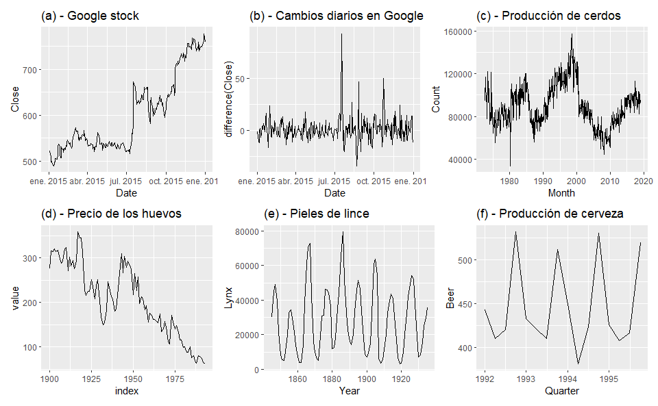

- Las series(a) y (d) presentan una tendencia (creciente y decreciente, respectivamente), por lo que **no** pueden ser **estacionarias**.
- Las series (c) y (f) muestran un componente estacional marcado, por lo que **no** pueden ser **estacionarias**.
- La serie (b) sí parece ser **estacionaria**. También muestra que hay un outlier en los datos.
- La serie (e) pareciera tener un patrón estacional. Sin embargo, al observarla detalladamente, vemos que el comportamiento cíclico no tiene una periodicidad fija, por lo que no es estacionalidad. Esta serie también es **estacionaria**.

### Diferenciación

Si observamos las gráficas anteriores, vemos que el precio de la acción de Google es no estacionario, mientras que los cambios diarios en el precio de la acción sí lo son. Así, encontramos que *una manera de convertir una serie en estacionaria es calculando las diferencias entre observaciones consecutivas*. A esto se le llama **diferenciar** la serie.

$$y_{t}^{\prime}=y_{t}-y_{t-1}$$

Los datos en primeras diferencias tendrán $T - 1$ observaciones, porque no es posible calcular la diferencia para la primera observación.

- Las transformaciones logarítmicas pueden ayudar a **estabilizar la varianza** de una serie.
- La diferenciación puede ayudar a **estabilizar la media** de una serie de tiempo, al quitar los cambios de nivel en ella y reducir o eliminar tendencia o estacionalidad.

Otra forma de determinar gráficamente si una serie de tiempo es estacionaria o no, es viendo su función de autocorrelación, ACF. Para una serie de tiempo estacionaria, la ACF se vuelve cero rápidamente, mientras que una serie no estacionaria decae lentamente y el valor del primer rezago es muy alto y positivo.

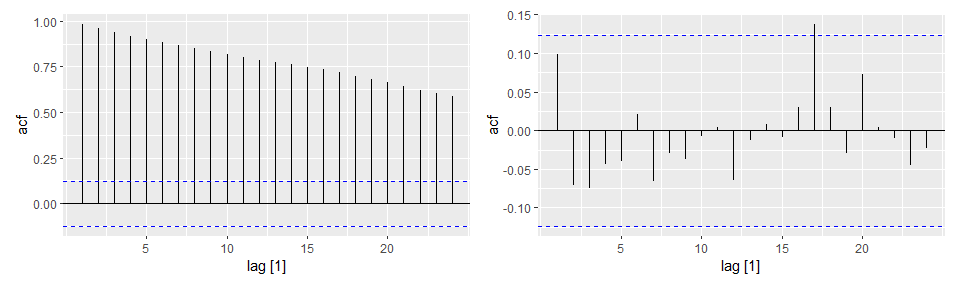

```r
google_2015 %>% ACF(Close) %>% autoplot() |
  google_2015 %>% ACF(diff_close) %>% autoplot()
```

Como habíamos visto, la significancia de las autocorrelaciones puede probarse mediante los estadísticos de Ljung-Box o Box-Pierce:

```r
google_2015 %>%
  features(diff_close, ljung_box, lag = 10)
```

| Symbol | lb_stat | lb_pvalue |
| --- | --- | --- |
| GOOG | 7.950738 | 0.6336489 |

La prueba indica que no son significativas las autocorrelaciones en la serie diferenciada.

### Diferenciación de segundo orden

A veces, la serie diferenciada parecerá seguir siendo no estacionaria, por lo que se puede recurrir a las **segundas diferencias**. Esto es, diferenciar las primeras diferencias:

$$\begin{aligned}
y_{t}^{\prime \prime} &=y_{t}^{\prime}-y_{t-1}^{\prime} \\
&=\left(y_{t}-y_{t-1}\right)-\left(y_{t-1}-y_{t-2}\right) \\
&=y_{t}-2 y_{t-1}+y_{t-2}
\end{aligned}$$

La serie en segundas diferencias tendrá $T-2$ observaciones. La interpretacion de $y_{t}^{\prime \prime}$ es que representa *los cambios en los cambios* de la serie.

**NOTA:** *En la práctica, casi nunca se requerirá ir más allá de las segundas diferencias, para lograr estacionariedad en la serie.*

### Diferenciación estacional

Este tipo de diferenciación es la diferencia que existe entre una observación y la observación previa, de la misma estación:

$$y_{t}^{\prime}=y_{t}-y_{t-m}$$

donde $m$ es el número de estaciones. También se le conoce como “lag-$m$ differences”.

A veces, es necesario tomar diferencias estacionales y primeras diferencias, para lograr que la serie se convierta en estacionaria. P. ej., tomemos las ventas de medicamentos corticosteroides.

1. Se transforma logarítmicamente la serie.
2. Se sacan las diferencias estacionales.
3. Como todavía parecen un poco no estacionarias, se obtienen los cambios en las ventas (primeras diferencias).

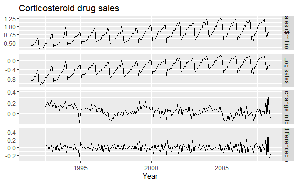

```r
PBS %>%
  filter(ATC2 == "H02") %>%
  summarise(Cost = sum(Cost)/1e6) %>%
  transmute(
    `Sales ($million)` = Cost,
    `Log sales` = log(Cost),
    `Annual change in log sales` = difference(log(Cost), 12),
    `Doubly differenced log sales` = difference(difference(log(Cost), 12), 1)
  ) %>%
  gather("Type", "Sales", !!!syms(measured_vars(.)), factor_key = TRUE) %>%
  ggplot(aes(x = Month, y = Sales)) +
  geom_line() +
  facet_grid(vars(Type), scales = "free_y") +
  labs(title = "Corticosteroid drug sales", x = "Year", y = NULL)
```

**NOTA:** *El orden en que se realiza la diferenciación no afecta el resultado (P. ej. primero realizar la diferenciación estacional y luego las primeras diferencias o al revés).* Sin embargo, si los datos tienen un componente estacional bien marcado, se recomienda realizar primero la diferenciación estacional, ya que la serie puede volverse estacionaria solo con esa diferenciación.

En la práctica, algún analista pudo haber concluido que la serie con diferencias estacionales ya era estacionaria, mientras que otro pudo haber obtenido también las primeras diferencias.

Cuando se realiza la diferenciación, es importante que esta sea interpretable:

- Las primeras diferencias son los cambios de una observación a la siguiente.
- Las diferencias estacionales son los cambios de un año a otro.

No se recomienda utilizar otro rezago (p. ej. los cambios entre la primera y décimo octava observación, ya que es difícil encontrarle una interpretación lógica).

### Pruebas de raíz unitaria

Para poder determinar más formalmente si una serie es estacionaria o no, se pueden llevar a cabo pruebas de **raíz unitaria**.

Existen muchas pruebas distintas de raíz unitaria. Utilizaremos, por lo pronto la prueba propuesta por *Kwiatkowski-Phillips-Schmidt-Shin*, o prueba KPSS en corto. Aquí, la $H_0$ es que la serie es estacionaria. Por lo tanto, un *p-value* alto indicará que sí es estacionaria, mientras que un *p-value* $<\alpha$ indicará que la serie no es estacionaria.

Entonces, el precio de la acción de Google es no estacionario de acuerdo a la prueba KPSS:

```r
google_2015 %>%
  features(Close, unitroot_kpss)
```

| Symbol | kpss_stat | kpss_pvalue |
| --- | --- | --- |
| GOOG | 3.560958 | 0.01 |

mientras que las primeras diferencias sí lo son:

```r
google_2015 %>%
  features(diff_close, unitroot_kpss)
```

| Symbol | kpss_stat | kpss_pvalue |
| --- | --- | --- |
| GOOG | 0.1016839 | 0.1 |

Podemos utilizar la función `unitroot_ndiffs()` para encontrar el orden de diferenciación necesario para convertir la serie en estacionaria:

```r
google_2015 %>%
  features(Close, unitroot_ndiffs)
```

| Symbol | ndiffs |
| --- | --- |
| GOOG | 1 |

Tal como lo habíamos visto, esto nos indica que se requieren las primeras diferencias para convertir la serie en estacionaria.

Una característica similar para determinar si se requiere diferenciación estacional se puede obtener con `unitroot_nsdiffs()`.

Tomemos el ejemplo de las ventas minoristas:

```
Plot variable not specified, automatically selected `.vars = Turnover`
```

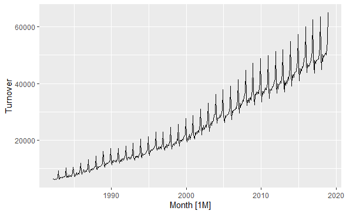

```r
aus_total_retail <- aus_retail %>%
  summarise(Turnover = sum(Turnover))
autoplot(aus_total_retail)
```

Se puede ver que la serie en niveles no es estacionaria: tiene una tendencia creciente y una estacionalidad fuerte. La varianza de la serie ha ido creciendo, por lo que sacamos los logaritmos primero para estabilizarla.

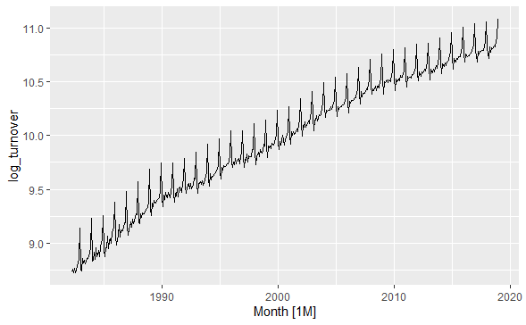

```r
aus_total_retail <- aus_total_retail %>%
  mutate(log_turnover = log(Turnover))

aus_total_retail %>% autoplot(log_turnover)
```

La transformación logarítmica fue adecuada para estabilizar la varianza de esta serie.

Vemos el orden de diferenciación estacional:

```r
aus_total_retail %>%
  features(log_turnover, unitroot_nsdiffs)
```

| nsdiffs |
| --- |
| 1 |

La prueba nos indica que se requiere una diferenciación estacional. Revisamos si, adicionalmente, se necesitan sacar las primeras diferencias:

```r
aus_total_retail %>%
  mutate(log_turnover = difference(log(Turnover), 12)) %>%
  features(log_turnover, unitroot_ndiffs)
```

| ndiffs |
| --- |
| 1 |

Así, estas funciones nos indican que se requieren ambas: una diferenciación estacional y las primeras diferencias para hacer la serie estacionaria.

### Notación de rezagos y diferencias

Se puede utilizar el operador *B* para representar rezagos en las series de tiempo:

$$B y_{t}=y_{t-1}$$
Para marcar dos periodos atrás (el segundo rezago), podríamos utilizar $B^2$:

$$B^2 y_{t}=y_{t-2}$$
Para datos trimestrales, si quisiéramos expresar “el mismo trimestre del año pasado”, utilizaríamos la notación $B^4y_t = y_{t-4}$. Para datos mensuales, obtener "el mismo mes del año anterior, utilizaríamos $B^{12}y_t = y_{t-12}$.

El operador *B* también se puede usar para expresar la diferenciación de una serie:

$$y_{t}^{\prime}=y_{t}-y_{t-1}=y_{t}-B y_{t}=(1-B) y_{t}$$

Así, las primeras diferencias están dadas por $(1-B)$. Las segundas diferencias:

$$y_{t}^{\prime \prime}=y_{t}-2 y_{t-1}+y_{t-2}=\left(1-2 B+B^{2}\right) y_{t}=(1-B)^{2} y_{t}$$

Entonces, la diferencia de orden *d* estaría dada por

$$(1-B)^d y_t$$

La notación del operador *B* es más útil cuando se combinan diferencias. P. ej. una serie de tiempo que requiera tomar las primeras diferencias y diferencias estacionales se podría escribir así

$$\begin{aligned}
(1-B)\left(1-B^{m}\right) y_{t} &=\left(1-B-B^{m}+B^{m+1}\right) y_{t} \\
&=y_{t}-y_{t-1}-y_{t-m}+y_{t-m-1}
\end{aligned}$$

Como se puede observar, *B* sigue las reglas algebraicas.

# Modelos autorregresivos

Un modelo autorregresivo de orden *p* se define como

$$y_{t}=\phi_0+\phi_{1} y_{t-1}+\phi_{2} y_{t-2}+\cdots+\phi_{p} y_{t-p}+\varepsilon_{t}$$
donde $\varepsilon_{t}$ es ruido blanco. Si observamos bien la ecuación, se asemeja mucho a una ecuación de regresión lineal múltiple, con la diferencia de que, ahora, los parámetros no son $\beta$, sino $\phi$ y que las regresoras (variables $x$), ahora son valores rezagados de la variable dependiente, $y_t$. Este sería un **modelo AR(*p*)**: modelo autorregresivo de orden *p*.

Dos ejemplos de modelos autorregresivos:

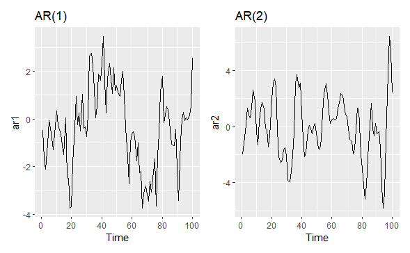